# Insurance claim analysis

Andrew Crater

2024-12-12

### Load packages

```r
library(ggplot2)
library(tree)
library(factoextra)
library(dplyr)
library(cluster)
library(randomForest)
```

### Part 1: Load the data, log charges, create train and test sets

```r
df <- read.csv('insurance.csv')

df$log_charges <- log(df$charges)

set.seed(1)

index <- sample(1:nrow(df), size = round(0.7*nrow(df)))

train <- df[index, ]
test <- df[-index, ]
```

Now we can check out the data

```r
summary(train)
```

```
##       age           sex                 bmi           children
##  Min.   :18.0   Length:937         Min.   :15.96   Min.   :0.000
##  1st Qu.:27.0   Class :character   1st Qu.:26.20   1st Qu.:0.000
##  Median :39.0   Mode  :character   Median :30.40   Median :1.000
##  Mean   :39.3                      Mean   :30.60   Mean   :1.091
##  3rd Qu.:51.0                      3rd Qu.:34.58   3rd Qu.:2.000
##  Max.   :64.0                      Max.   :53.13   Max.   :5.000
##     smoker             region             charges       log_charges
##  Length:937         Length:937         Min.   : 1132   Min.   : 7.031
##  Class :character   Class :character   1st Qu.: 4718   1st Qu.: 8.459
##  Mode  :character   Mode  :character   Median : 9250   Median : 9.132
##                                        Mean   :13034   Mean   : 9.085
##                                        3rd Qu.:15555   3rd Qu.: 9.652
##                                        Max.   :62593   Max.   :11.044
```

We see that we can make sex, smoker, and region into factors.

```r
train$sex <- as.factor(train$sex)
train$smoker <- as.factor(train$smoker)
train$region <- as.factor(train$region)

test$sex <- as.factor(test$sex)
test$smoker <- as.factor(test$smoker)
test$region <- as.factor(test$region)
```

### Part 2: Building a linear regression model

```r
lin_model = lm(log_charges ~ age + sex + smoker+bmi+children+ region, data= train)
summary(lin_model)
```

```
##
## Call:
## lm(formula = log_charges ~ age + sex + smoker + bmi + children +
##     region, data = train)
##
## Residuals:
##      Min       1Q   Median       3Q      Max
## -1.03264 -0.17316 -0.03963  0.06375  2.12005
##
## Coefficients:
##                  Estimate Std. Error t value Pr(>|t|)
## (Intercept)      7.049426   0.081342  86.664  < 2e-16 ***
## age              0.034992   0.001004  34.861  < 2e-16 ***
## sexmale         -0.056257   0.027925  -2.015 0.044236 *
## smokeryes        1.541332   0.034738  44.370  < 2e-16 ***
## bmi              0.011504   0.002394   4.805  1.8e-06 ***
## children         0.100120   0.011620   8.616  < 2e-16 ***
## regionnorthwest -0.090565   0.039662  -2.283 0.022630 *
## regionsoutheast -0.142457   0.039310  -3.624 0.000306 ***
## regionsouthwest -0.112014   0.040209  -2.786 0.005448 **
## ---
## Signif. codes:  0 '***' 0.001 '**' 0.01 '*' 0.05 '.' 0.1 ' ' 1
##
## Residual standard error: 0.4246 on 928 degrees of freedom
## Multiple R-squared:  0.7845, Adjusted R-squared:  0.7827
## F-statistic: 422.4 on 8 and 928 DF,  p-value: < 2.2e-16
```

From our model, we can see from the p-value that age, sex, smoker, bmi, children, and region all have significant impact on charges. Sex does indeed have a significant impact on the response. We can see from the coefficient that being male has a negative impact on our response, since the coefficient is negative. Now we will make predictions in order to calculate the rmse.

```r
linear_predictions <- predict(lin_model, newdata = test)
linear_rmse <- sqrt(mean((test$log_charges - linear_predictions)^2))
print(linear_rmse)
```

```
## [1] 0.4892747
```

### Part 3: Building a regression tree model

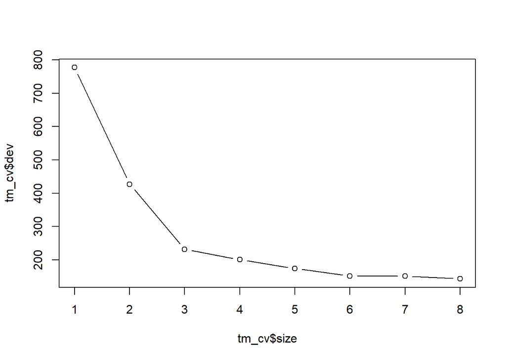

```r
tree_model <- tree(log_charges ~ age + sex + smoker+bmi+children+ region, data= train)
tm_cv <- cv.tree(tree_model)
plot(tm_cv$size, tm_cv$dev, type='b')
```

Here, we can tell that three is the optimal number of clusters, as it is the elbow point in the graph. This is generally represents a good point with regards to the variance-bias tradeoff. That is to say there is not that much of a drop in variances in branches beyond 3, which means that additional bias towards this dataset, as well as significant computational complexity will be introduced inefficiently beyond this point. We can now proceed with pruning the tree.

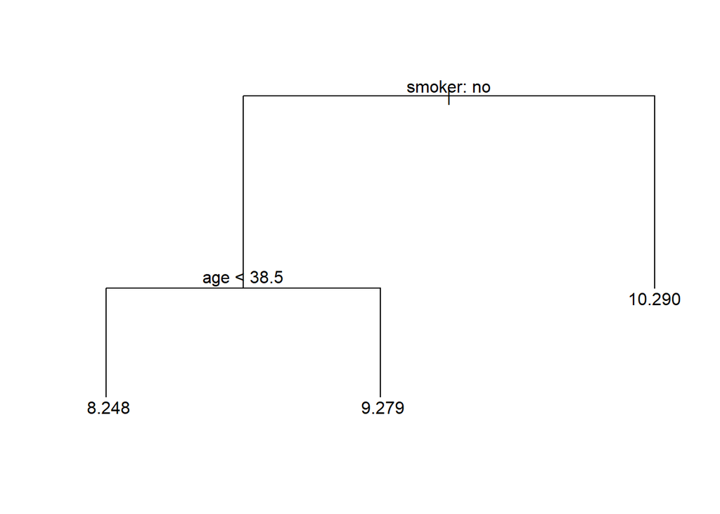

```r
insurance_prune <- prune.tree(tree_model, best=3)
plot(insurance_prune)
text(insurance_prune, pretty=0)
```

```r
yhat <- predict(insurance_prune, newdata = test)
test_results <- test[, 'log_charges']
tree_rmse <- mean((yhat - test_results)^2)
tree_rmse
```

```
## [1] 0.2979018
```

### Part 4: Building a random forest model.

```r
rf_insurance <- randomForest(log_charges ~ age + sex + smoker+bmi+children+ region, data= train, importance= TRUE)
```

```r
rf_yhat <- predict(rf_insurance, newdata=test)
rf_test_results <- test[, 'log_charges']
rf_rmse <- mean((rf_yhat -rf_test_results)^2)
rf_rmse
```

```
## [1] 0.1867766
```

```r
importance(rf_insurance)
```

```
##             %IncMSE IncNodePurity
## age      103.240158    248.643942
## sex        1.460505      6.917457
## smoker   145.691046    329.997250
## bmi       21.955607     58.679135
## children  31.430673     33.950714
## region     9.058671     17.182018
```

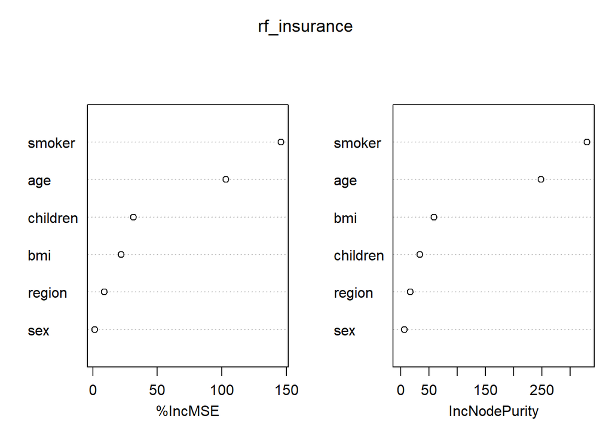

```r
varImpPlot(rf_insurance)
```

### Part 5: k-means cluster analysis

First, we need to remove the data that is non-numerical, as mentioned in the instructions,

```r
train_new <- train %>% select(-sex, -region, -charges, -smoker)
test_new <- test %>% select(-sex, -region, -charges, -smoker)
```

Now we can figure out the correct number of clusters.

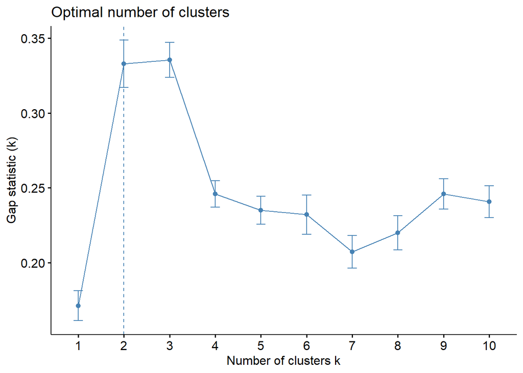

```r
fviz_nbclust(train_new, kmeans, method='gap_stat')
```

We can see that the best number of clusters according to the gap statistic method is 2, as it is almost equal to 3, but two requires less computing power, so we should use less when we can. We can also try with the silhouette method to see if it comes to the same conclusion. Note: A higher gap statistic is better, as it measures the average gap between clusters, a higher number means more distinction between clusters.

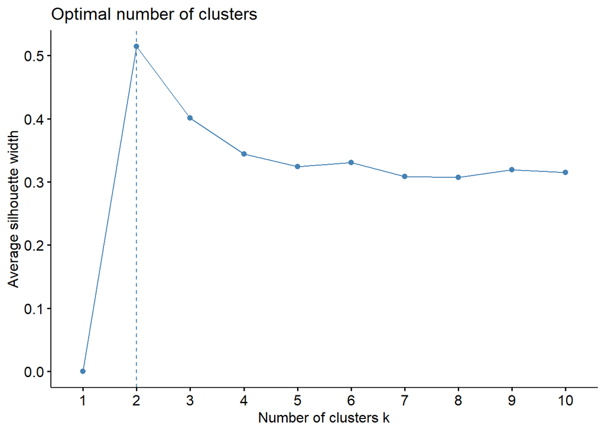

```r
fviz_nbclust(train_new, kmeans, method='silhouette')
```

The silhouette method also found that two is the most efficient number of clusters to use with our data. Now we can visualize the clusters

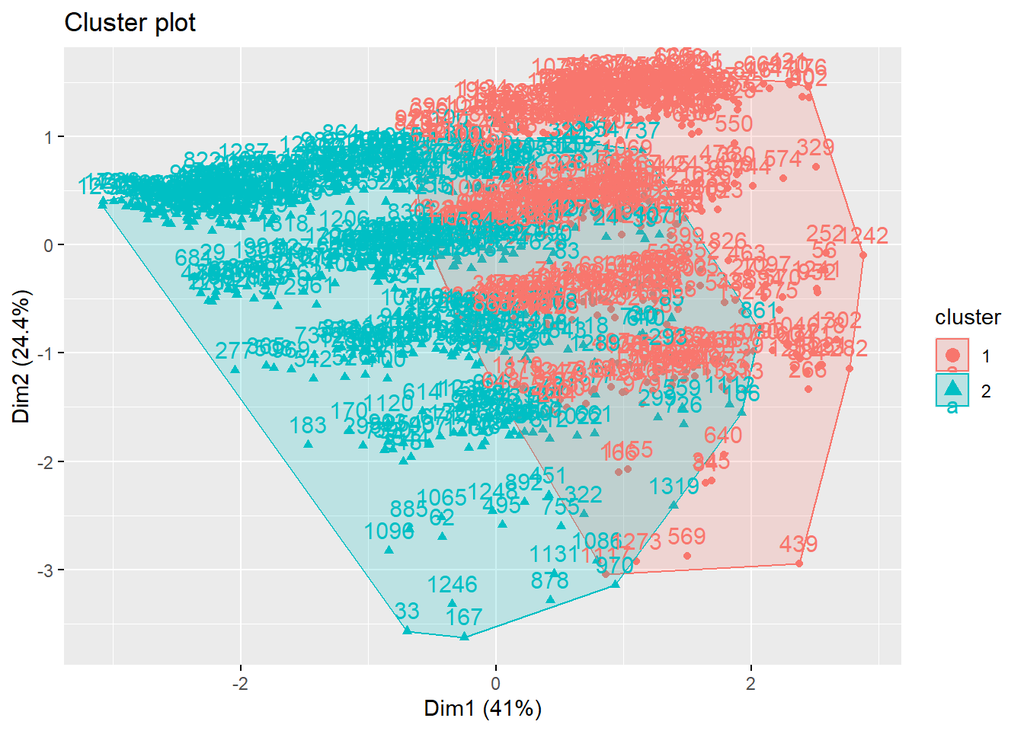

```r
km_result1<- kmeans(train_new, 2, nstart=25)
fviz_cluster(km_result1, data=train_new)
```

### Part 6: Putting it all together.

```r
Model.Type <- c("Multiple Linear Regression", "Regression Tree", "Random Forest")
Test.MSE <- c(round(linear_rmse,4), round(tree_rmse,4), round(rf_rmse, 4))
rm_compare <- data.frame(Model.Type, Test.MSE)
print(rm_compare)
```

```
##                   Model.Type Test.MSE
## 1 Multiple Linear Regression   0.4893
## 2            Regression Tree   0.2979
## 3              Random Forest   0.1868
```

In answer to the question regarding which model is easiest to visually demonstrate a feature, I recommend the a regression tree, as the logic of a decision tree is very easy to follow. I would recommend that model over most others if we are mostly focused on ease of understanding.

We can reverse the logarithmic transformation of the charges in order to demonstrate the output of the tree model most simply:

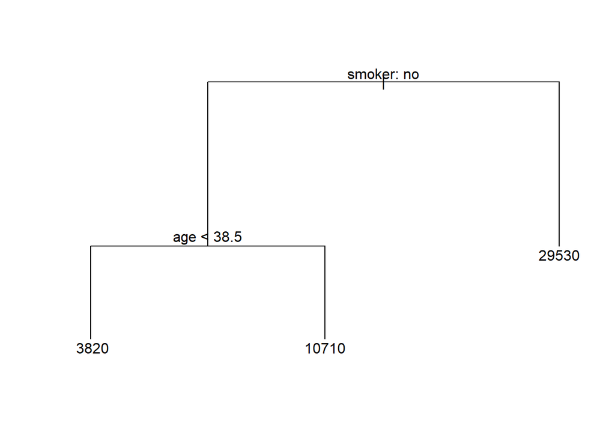

```r
prune.copy <- insurance_prune
prune.copy$frame$yval <- exp(prune.copy$frame$yval)
plot(prune.copy)
text(prune.copy, pretty=0)
```